# HW5_MeltonandBrink

Chad Melton

11/1/2020

```r
library(MASS)
library(rpart)
library(epiR)
```

```r
library(ggplot2)
library(vcdExtra)
library(vcd)
library(lmtest)
library(caret)
library(ROCR)
library(pROC)
crab = read.csv("C:\\Users\\chadm\\OneDrive\\Desktop\\Fall_2020\\STATS 578\\HW\\HW5\\crab.csv",header=TRUE)
```

## 5.10

For the horseshoe crab data, fit the logistic regression model with x = weight as the sole predictor of the presence of satellites.’

```r
crab.model <- glm(y~weight, data=crab, family=binomial(link="logit"))
summary(crab.model)
```

```
##
## Call:
## glm(formula = y ~ weight, family = binomial(link = "logit"),
##     data = crab)
##
## Deviance Residuals:
##     Min       1Q   Median       3Q      Max
## -2.1108  -1.0749   0.5426   0.9122   1.6285
##
## Coefficients:
##             Estimate Std. Error z value Pr(>|z|)
## (Intercept)  -3.6947     0.8802  -4.198 2.70e-05 ***
## weight        1.8151     0.3767   4.819 1.45e-06 ***
## ---
## Signif. codes:  0 '***' 0.001 '**' 0.01 '*' 0.05 '.' 0.1 ' ' 1
##
## (Dispersion parameter for binomial family taken to be 1)
##
##     Null deviance: 225.76  on 172  degrees of freedom
## Residual deviance: 195.74  on 171  degrees of freedom
## AIC: 199.74
##
## Number of Fisher Scoring iterations: 4
```

y=-3.6947 +1.8151x

1. For a classification table using the sample proportion of 0.642 as the cutoff, report the sensitivity and specificity. Interpret.’

```r
prob_pred = predict(crab.model, type = 'response')
y_thresh = ifelse(prob_pred > 0.642,1,0)
confusionMatrix(table(predict(crab.model, type="response") >= 0.642, crab$y == 1))
```

```
## Confusion Matrix and Statistics
##
##
##         FALSE TRUE
##   FALSE    45   43
##   TRUE     17   68
##
##                Accuracy : 0.6532
##                  95% CI : (0.5772, 0.7238)
##     No Information Rate : 0.6416
##     P-Value [Acc > NIR] : 0.408805
##
##                   Kappa : 0.3097
##
##  Mcnemar's Test P-Value : 0.001249
##
##             Sensitivity : 0.7258
##             Specificity : 0.6126
##          Pos Pred Value : 0.5114
##          Neg Pred Value : 0.8000
##              Prevalence : 0.3584
##          Detection Rate : 0.2601
##    Detection Prevalence : 0.5087
##       Balanced Accuracy : 0.6692
##
##        'Positive' Class : FALSE
##
```

2. Form a ROC curve, and report and interpret the area under it.

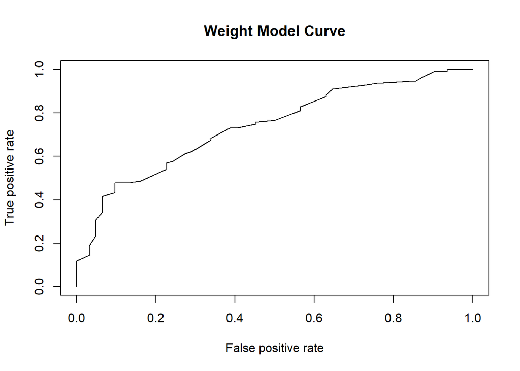

```r
crab.fit = predict(crab.model, type = "response")
pred.roc = prediction(crab.fit, crab$y)
perf.roc = performance(pred.roc,"tpr","fpr")
plot(perf.roc, main = "Weight Model Curve")
```

```r
library(pROC)
rocCurve=roc(response = crab$y,predictor = crab.fit)
auc(rocCurve)
```

```
## Area under the curve: 0.7379
```

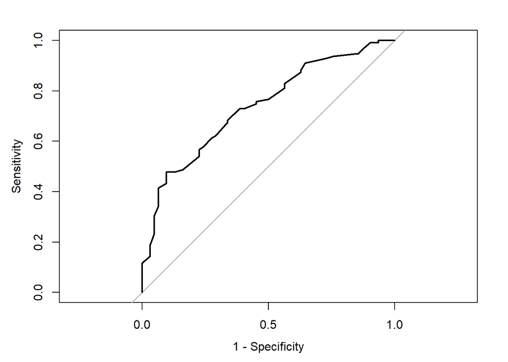

```r
plot(rocCurve,legacy.axes=TRUE)
```

```r
ci(rocCurve)
```

```
## 95% CI: 0.6631-0.8128 (DeLong)
```

c. Investigate the model goodness-of-fit using the Hosmer–Lemeshowstatistic or some other model-checking approach. Interpret.

```r
library(ResourceSelection)
```

```
## ResourceSelection 0.3-5   2019-07-22
```

```r
hos = hoslem.test(crab.model$y, fitted(crab.model), g = 10)
hos
```

```
##
##  Hosmer and Lemeshow goodness of fit (GOF) test
##
## data:  crab.model$y, fitted(crab.model)
## X-squared = 7.8334, df = 8, p-value = 0.4499
```

Here, Hosmer and Lemeshow goodness of fit (GOF) test provides a p-value of 0.4499 which is substantially greater than 0.05. Therefore, we will fail to reject the null hypothesis that the model is a bad fit.’

4. Inferentially compare the model to the model with x and x2 as predictors. Interpret.’

```r
crab.model2 <- glm(y~weight+weight2, data=crab, family=binomial(link="logit"))
summary(crab.model2)
```

```
##
## Call:
## glm(formula = y ~ weight + weight2, family = binomial(link = "logit"),
##     data = crab)
##
## Deviance Residuals:
##     Min       1Q   Median       3Q      Max
## -2.1825  -1.0739   0.5197   0.9391   1.5430
##
## Coefficients:
##             Estimate Std. Error z value Pr(>|z|)
## (Intercept)  -1.8877     3.5492  -0.532    0.595
## weight        0.2182     3.0816   0.071    0.944
## weight2       0.3393     0.6543   0.519    0.604
##
## (Dispersion parameter for binomial family taken to be 1)
##
##     Null deviance: 225.76  on 172  degrees of freedom
## Residual deviance: 195.46  on 170  degrees of freedom
## AIC: 201.46
##
## Number of Fisher Scoring iterations: 5
```

For the first crab model, the equation is y = -3.6947 + 1.8151x where the model with weight^2 is y = -1.8877+ 0.2182x + 0.3393x^2. The intercept and coefficients for the first model are significant where as adding weight^2 drastically changes the significance. weight 1.8151  
e. Compare the models in (d) using the AIC. Interpret.’ AIC(crab.model) AIC(crab.model2) The AIC goodness of fit test suggests that crab.model is better fit than crab.model2 (199.7371<201.4605)’

##5.20

Refer to Table 2.7 on mother’s drinking and infant malformations.’

```r
birthdefects <- matrix(
  c(17066, 48, 0.0,14464,38,0.5, 788,5,1.5, 126,1,4.0, 37,1, 7.0), nrow=5, ncol=3, byrow=TRUE)
dimnames(birthdefects) <- list(alcohol=c("0","<1", "1-2", "3-5",">=6"),
                               defects=c( "No", "Yes", "Scores"))

as.data.frame(birthdefects)
```

```
##        No Yes Scores
## 0   17066  48    0.0
## <1  14464  38    0.5
## 1-2   788   5    1.5
## 3-5   126   1    4.0
## >=6    37   1    7.0
```

```r
birthdefects = as.data.frame(birthdefects)

bdfcts.model = glm(cbind(Yes, No)~Scores,data=birthdefects,family=binomial)
summary(bdfcts.model)
```

```
##
## Call:
## glm(formula = cbind(Yes, No) ~ Scores, family = binomial, data = birthdefects)
##
## Deviance Residuals:
##       0       <1      1-2      3-5      >=6
##  0.5921  -0.8801   0.8865  -0.1449   0.1291
##
## Coefficients:
##             Estimate Std. Error z value Pr(>|z|)
## (Intercept)  -5.9605     0.1154 -51.637   <2e-16 ***
## Scores        0.3166     0.1254   2.523   0.0116 *
## ---
## Signif. codes:  0 '***' 0.001 '**' 0.01 '*' 0.05 '.' 0.1 ' ' 1
##
## (Dispersion parameter for binomial family taken to be 1)
##
##     Null deviance: 6.2020  on 4  degrees of freedom
## Residual deviance: 1.9487  on 3  degrees of freedom
## AIC: 24.576
##
## Number of Fisher Scoring iterations: 4
```

1. Fit the logistic regression model using scores {0, 0.5, 1.5, 4, 7} for alcohol consumption. Check goodness of fit.’

```r
bdfcts.model = glm(cbind(Yes, No)~Scores,data=birthdefects,family=binomial)
summary(bdfcts.model)
```

```
##
## Call:
## glm(formula = cbind(Yes, No) ~ Scores, family = binomial, data = birthdefects)
##
## Deviance Residuals:
##       0       <1      1-2      3-5      >=6
##  0.5921  -0.8801   0.8865  -0.1449   0.1291
##
## Coefficients:
##             Estimate Std. Error z value Pr(>|z|)
## (Intercept)  -5.9605     0.1154 -51.637   <2e-16 ***
## Scores        0.3166     0.1254   2.523   0.0116 *
## ---
## Signif. codes:  0 '***' 0.001 '**' 0.01 '*' 0.05 '.' 0.1 ' ' 1
##
## (Dispersion parameter for binomial family taken to be 1)
##
##     Null deviance: 6.2020  on 4  degrees of freedom
## Residual deviance: 1.9487  on 3  degrees of freedom
## AIC: 24.576
##
## Number of Fisher Scoring iterations: 4
```

```r
pchisq(1.9487,3, lower.tail = FALSE)
```

```
## [1] 0.5831222
```

The test provides a p-value of 0.58 which suggests we fail to reject the null hypothesis that the model has a poor fit. This conclusion is supported by the ratio Residual Deviance to degrees of freedom ~2/3

b. Test independence using the likelihood-ratio test for the model in (a). (The trend test of Section 2.5.1 is the score test for this model.)’

```r
lrtest (bdfcts.model)
```

```
## Likelihood ratio test
##
## Model 1: cbind(Yes, No) ~ Scores
## Model 2: cbind(Yes, No) ~ 1
##   #Df  LogLik Df  Chisq Pr(>Chisq)
## 1   2 -10.288
## 2   1 -12.414 -1 4.2533    0.03917 *
## ---
## Signif. codes:  0 '***' 0.001 '**' 0.01 '*' 0.05 '.' 0.1 ' ' 1
```

‘c. The sample proportion of malformations is much higher in the highest alcohol category because, although it has only one malformation, its sample size is only 38. Are the results sensitive to this single observation? Re-fit the model without it, entering 0 malformations for 37 observations, and compare the results of the likelihood-ratio test. (Because results are sensitive to a single observation, it is hazardous to make conclusions, even though n was extremely large.)’

```r
birthdefects2 <- matrix(
  c(17066, 48, 0.0,14464,38,0.5, 788,5,1.5, 126,1,4.0, 0,1, 7.0), nrow=5, ncol=3, byrow=TRUE)
dimnames(birthdefects2) <- list(alcohol=c("0","<1", "1-2", "3-5",">=6"),
                               defects=c( "No", "Yes", "Scores"))


birthdefects2 = as.data.frame(birthdefects2)

bdfcts2.model = glm(cbind(Yes, No)~Scores,data=birthdefects2,family=binomial)
summary(bdfcts2.model)
```

```
##
## Call:
## glm(formula = cbind(Yes, No) ~ Scores, family = binomial, data = birthdefects2)
##
## Deviance Residuals:
##       0       <1      1-2      3-5      >=6
##  0.9454  -1.0828   0.4853  -0.8679   2.3188
##
## Coefficients:
##             Estimate Std. Error z value Pr(>|z|)
## (Intercept)  -6.0135     0.1210 -49.685  < 2e-16 ***
## Scores        0.4851     0.1547   3.135  0.00172 **
## ---
## Signif. codes:  0 '***' 0.001 '**' 0.01 '*' 0.05 '.' 0.1 ' ' 1
##
## (Dispersion parameter for binomial family taken to be 1)
##
##     Null deviance: 15.2389  on 4  degrees of freedom
## Residual deviance:  8.4319  on 3  degrees of freedom
## AIC: 29.085
##
## Number of Fisher Scoring iterations: 4
```

```r
lrtest (bdfcts2.model)
```

```
## Likelihood ratio test
##
## Model 1: cbind(Yes, No) ~ Scores
## Model 2: cbind(Yes, No) ~ 1
##   #Df  LogLik Df Chisq Pr(>Chisq)
## 1   2 -12.543
## 2   1 -15.946 -1 6.807    0.00908 **
## ---
## Signif. codes:  0 '***' 0.001 '**' 0.01 '*' 0.05 '.' 0.1 ' ' 1
```

```r
birthdefects3 <- matrix(
  c(17066, 48, 1,14464,38,2, 788,5,3, 126,1,4.0, 0,1, 5), nrow=5, ncol=3, byrow=TRUE)
dimnames(birthdefects3) <- list(alcohol=c("0","<1", "1-2", "3-5",">=6"),
                                defects=c( "No", "Yes", "Scores"))

birthdefects3 = as.data.frame(birthdefects3)

bdfcts3.model = glm(cbind(Yes, No)~Scores,data=birthdefects3,family=binomial)
summary(bdfcts2.model)
```

```
##
## Call:
## glm(formula = cbind(Yes, No) ~ Scores, family = binomial, data = birthdefects2)
##
## Deviance Residuals:
##       0       <1      1-2      3-5      >=6
##  0.9454  -1.0828   0.4853  -0.8679   2.3188
##
## Coefficients:
##             Estimate Std. Error z value Pr(>|z|)
## (Intercept)  -6.0135     0.1210 -49.685  < 2e-16 ***
## Scores        0.4851     0.1547   3.135  0.00172 **
## ---
## Signif. codes:  0 '***' 0.001 '**' 0.01 '*' 0.05 '.' 0.1 ' ' 1
##
## (Dispersion parameter for binomial family taken to be 1)
##
##     Null deviance: 15.2389  on 4  degrees of freedom
## Residual deviance:  8.4319  on 3  degrees of freedom
## AIC: 29.085
##
## Number of Fisher Scoring iterations: 4
```

```r
pchisq(8.4319,3,lower.tail = FALSE )
```

```
## [1] 0.03788009
```

## 5.21

```r
birthdefects <- matrix(
  c(17066, 48, 14464,38,788,5,126,1,37,1), nrow=5, ncol=2, byrow=TRUE)
dimnames(birthdefects) <- list(alcohol=c("0","<1", "1-2", "3-5",">=6"),
                               defects=c("Yes", "No"))
fisher.test(birthdefects)
```

```
##
##  Fisher's Exact Test for Count Data
##
## data:  birthdefects
## p-value = 0.03336
## alternative hypothesis: two.sided
```

## Problem 5.23

### Part a

We start the problem by fitting the model to the data as requested.

```r
library(survival)
library(MASS)
library(lmtest)
data23=read.csv(".\\Pr5.23.csv")
data23.fit=glm(cbind(response,count)~delay+pen1+pen2+pen3+pen4+pen5-1,data=data23,family=binomial(link="logit"))
summary(data23.fit)
```

```
##
## Call:
## glm(formula = cbind(response, count) ~ delay + pen1 + pen2 +
##     pen3 + pen4 + pen5 - 1, family = binomial(link = "logit"),
##     data = data23)
##
## Deviance Residuals:
##     Min       1Q   Median       3Q      Max
## -1.5556  -1.0018   0.0000   0.6775   2.0004
##
## Coefficients:
##       Estimate Std. Error z value Pr(>|z|)
## delay  -0.1249     0.6980  -0.179   0.8580
## pen1   -1.6484     0.8280  -1.991   0.0465 *
## pen2   -1.7307     0.8335  -2.076   0.0379 *
## pen3   -1.7307     0.8335  -2.076   0.0379 *
## pen4   -1.7307     0.8335  -2.076   0.0379 *
## pen5   -1.1705     0.9219  -1.270   0.2042
## ---
## Signif. codes:  0 '***' 0.001 '**' 0.01 '*' 0.05 '.' 0.1 ' ' 1
##
## (Dispersion parameter for binomial family taken to be 1)
##
##     Null deviance: 59.558  on 17  degrees of freedom
## Residual deviance: 25.950  on 11  degrees of freedom
## AIC: 48.37
##
## Number of Fisher Scoring iterations: 4
```

We see that the last coefficient in the penicillan category has a very insignificant p-value. For the first value, the model gives us a significant coefficient that is within the realm of possibility. We can see from the data that these values should approach infinity and negative infinity respectively. However the answers reported make logical sense if we just look at the values. This indicates that the model does not perform as expected when zeros are present. It should also be noted that if this model is run with an intercept term, the last penicillan vlaue is null and the first has a much larger standard deviation.

### Part b

Here we run the models for each of the likelihood ratios.

```r
data23b=read.csv(".\\Pr5.23_b.csv")
data23b.fit1=glm(cbind(response,count)~delay+pen1-1,data=data23,family=binomial(link="logit"))
lrtest(data23b.fit1)
```

```
## Likelihood ratio test
##
## Model 1: cbind(response, count) ~ delay + pen1 - 1
## Model 2: cbind(response, count) ~ 1
##   #Df  LogLik Df  Chisq Pr(>Chisq)
## 1   2 -24.824
## 2   1 -18.365 -1 12.917  0.0003256 ***
## ---
## Signif. codes:  0 '***' 0.001 '**' 0.01 '*' 0.05 '.' 0.1 ' ' 1
```

```r
data23b.fit2=glm(cbind(response,count)~delay+pen2-1,data=data23,family=binomial(link="logit"))
lrtest(data23b.fit2)
```

```
## Likelihood ratio test
##
## Model 1: cbind(response, count) ~ delay + pen2 - 1
## Model 2: cbind(response, count) ~ 1
##   #Df  LogLik Df  Chisq Pr(>Chisq)
## 1   2 -24.694
## 2   1 -18.365 -1 12.657  0.0003742 ***
## ---
## Signif. codes:  0 '***' 0.001 '**' 0.01 '*' 0.05 '.' 0.1 ' ' 1
```

```r
data23b.fit3=glm(cbind(response,count)~delay+pen3-1,data=data23,family=binomial(link="logit"))
lrtest(data23b.fit3)
```

```
## Likelihood ratio test
##
## Model 1: cbind(response, count) ~ delay + pen3 - 1
## Model 2: cbind(response, count) ~ 1
##   #Df  LogLik Df  Chisq Pr(>Chisq)
## 1   2 -24.694
## 2   1 -18.365 -1 12.657  0.0003742 ***
## ---
## Signif. codes:  0 '***' 0.001 '**' 0.01 '*' 0.05 '.' 0.1 ' ' 1
```

```r
data23b.fit4=glm(cbind(response,count)~delay+pen4-1,data=data23,family=binomial(link="logit"))
lrtest(data23b.fit4)
```

```
## Likelihood ratio test
##
## Model 1: cbind(response, count) ~ delay + pen4 - 1
## Model 2: cbind(response, count) ~ 1
##   #Df  LogLik Df  Chisq Pr(>Chisq)
## 1   2 -24.694
## 2   1 -18.365 -1 12.657  0.0003742 ***
## ---
## Signif. codes:  0 '***' 0.001 '**' 0.01 '*' 0.05 '.' 0.1 ' ' 1
```

```r
data23b.fit5=glm(cbind(response,count)~delay+pen5-1,data=data23,family=binomial(link="logit"))
lrtest(data23b.fit5)
```

```
## Likelihood ratio test
##
## Model 1: cbind(response, count) ~ delay + pen5 - 1
## Model 2: cbind(response, count) ~ 1
##   #Df  LogLik Df  Chisq Pr(>Chisq)
## 1   2 -26.089
## 2   1 -18.365 -1 15.448  8.482e-05 ***
## ---
## Signif. codes:  0 '***' 0.001 '**' 0.01 '*' 0.05 '.' 0.1 ' ' 1
```

```r
data23b.fit=glm(cbind(response,count)~delay+pen1+pen2+pen3+pen4+pen5-1,data=data23,family=binomial(link="logit"))
lrtest(data23b.fit)
```

```
## Likelihood ratio test
##
## Model 1: cbind(response, count) ~ delay + pen1 + pen2 + pen3 + pen4 +
##     pen5 - 1
## Model 2: cbind(response, count) ~ 1
##   #Df  LogLik Df  Chisq Pr(>Chisq)
## 1   6 -18.185
## 2   1 -18.365 -5 0.3602     0.9964
```

### Part c

Here we compare the odds ratios for the models to calculate the conditional odds ratio. This is the odds ratio of the model with all parameters over the model with the first parameter with the coefficient effect multiplied by five. If independent of x, this ratio should be equal to one.

```r
a=sum(exp(coef(data23b.fit)))
b=exp(coef(data23b.fit1))
c=b[1]+b[2]*5
odds=a/c
odds
```

```
##    delay
## 1.102125
```

Here the odds ratio is slightly above one, but greatly enough that we assume there is some sort of dependence between x and y.

## Problem 5.26

### Part a

We start this problem by loading the data and setting up a model for each feature. A brief discussion of each coefficient follows the model for that feature.

```r
tab15=read.csv(".\\Tab515.csv")
data.fitx1=glm(y~x1,data=tab15,family=binomial(link="logit"))
summary(data.fitx1)
```

```
##
## Call:
## glm(formula = y ~ x1, family = binomial(link = "logit"), data = tab15)
##
## Deviance Residuals:
##     Min       1Q   Median       3Q      Max
## -1.8043  -1.0472   0.5718   0.9677   1.3983
##
## Coefficients:
##             Estimate Std. Error z value Pr(>|z|)
## (Intercept)   0.1964     0.5012   0.392   0.6951
## x1           -0.6383     0.3808  -1.676   0.0937 .
## ---
## Signif. codes:  0 '***' 0.001 '**' 0.01 '*' 0.05 '.' 0.1 ' ' 1
##
## (Dispersion parameter for binomial family taken to be 1)
##
##     Null deviance: 27.910  on 20  degrees of freedom
## Residual deviance: 23.616  on 19  degrees of freedom
## AIC: 27.616
##
## Number of Fisher Scoring iterations: 5
```

For x1, we see that the model has a coefficient of -0.6383 and a standard deviation of 0.3808. Looking at the p-value, we see that this feature is not significant at a 95% confidence level. We now repeat the process for x2.

```r
data.fitx2=glm(y~x2,data=tab15,family=binomial(link="logit"))
summary(data.fitx2)
```

```
##
## Call:
## glm(formula = y ~ x2, family = binomial(link = "logit"), data = tab15)
##
## Deviance Residuals:
##     Min       1Q   Median       3Q      Max
## -1.5922  -0.5252   0.2119   0.6100   1.7382
##
## Coefficients:
##             Estimate Std. Error z value Pr(>|z|)
## (Intercept)  -0.7039     0.8506  -0.827   0.4080
## x2           -0.3096     0.1555  -1.991   0.0465 *
## ---
## Signif. codes:  0 '***' 0.001 '**' 0.01 '*' 0.05 '.' 0.1 ' ' 1
##
## (Dispersion parameter for binomial family taken to be 1)
##
##     Null deviance: 27.910  on 20  degrees of freedom
## Residual deviance: 16.158  on 19  degrees of freedom
## AIC: 20.158
##
## Number of Fisher Scoring iterations: 6
```

In this model, we see that x2 has a coefficient of -0.3096 and a standard deviation of 0.1555. This feature is significant at a confidence level of 95%. We repeat yet again for x3.

```r
data.fitx3=glm(y~x3,data=tab15,family=binomial(link="logit"))
summary(data.fitx3)
```

```
##
## Call:
## glm(formula = y ~ x3, family = binomial(link = "logit"), data = tab15)
##
## Deviance Residuals:
##     Min       1Q   Median       3Q      Max
## -1.5099  -1.3579   0.9435   0.9795   1.0921
##
## Coefficients:
##             Estimate Std. Error z value Pr(>|z|)
## (Intercept)  0.59052    0.53953   1.094    0.274
## x3           0.01171    0.03224   0.363    0.716
##
## (Dispersion parameter for binomial family taken to be 1)
##
##     Null deviance: 27.910  on 20  degrees of freedom
## Residual deviance: 27.778  on 19  degrees of freedom
## AIC: 31.778
##
## Number of Fisher Scoring iterations: 4
```

In this final (for part a) model, we see that the feature x3 has a coefficient of 0.0117 and a standard deviation of 0.03224. The standard deviation is nearly three times the value of the coefficient so we are highly suspicious of the quality of this model. We can see that this feature is insginificant.

### Part b

Now we look at a main features model containing a coefficient for each feature. We set up this model and run it below.

```r
data.fit=glm(y~x1+x2+x3,data=tab15,family=binomial(link="logit"))
summary(data.fit)
```

```
##
## Call:
## glm(formula = y ~ x1 + x2 + x3, family = binomial(link = "logit"),
##     data = tab15)
##
## Deviance Residuals:
##        Min          1Q      Median          3Q         Max
## -1.056e-03  -2.000e-08   2.000e-08   2.000e-08   1.038e-03
##
## Coefficients:
##             Estimate Std. Error z value Pr(>|z|)
## (Intercept)   -83.84    2879.50  -0.029    0.977
## x1          -2445.04   79162.56  -0.031    0.975
## x2          -1653.76   53562.97  -0.031    0.975
## x3            310.27   10043.85   0.031    0.975
##
## (Dispersion parameter for binomial family taken to be 1)
##
##     Null deviance: 2.7910e+01  on 20  degrees of freedom
## Residual deviance: 3.3402e-06  on 17  degrees of freedom
## AIC: 8
##
## Number of Fisher Scoring iterations: 25
```

### Part c

We originally had this set up in R, however as the results did not make sense and Dr. Zaretzki said that this did not perform as desired we tried to set this up in SAS we ran out of time to produce this code and could not re-do the problem in SAS with our other responsibilites between class and the due date. Thank you for your understanding. Below is the rcode used that did not make sense.

```r
data.conditional=clogit(y~x1+x2+x3,data=tab15,method="exact")
summary(data.conditional)
```

```
## Call:
## coxph(formula = Surv(rep(1, 21L), y) ~ x1 + x2 + x3, data = tab15,
##     method = "exact")
##
##   n= 21, number of events= 13
##
##    coef exp(coef) se(coef)  z Pr(>|z|)
## x1   NA        NA        0 NA       NA
## x2   NA        NA        0 NA       NA
## x3   NA        NA        0 NA       NA
##
##    exp(coef) exp(-coef) lower .95 upper .95
## x1        NA         NA        NA        NA
## x2        NA         NA        NA        NA
## x3        NA         NA        NA        NA
##
## Concordance= 0.99  (se = 0.013 )
## Likelihood ratio test= 21.57  on 0 df,   p=<2e-16
## Wald test            = NA  on 0 df,   p=NA
## Score (logrank) test = 12.01  on 0 df,   p=<2e-16
```

```r
data.conditional1=clogit(y~x1,data=tab15,method="exact")
summary(data.conditional1)
```

```
## Call:
## coxph(formula = Surv(rep(1, 21L), y) ~ x1, data = tab15, method = "exact")
##
##   n= 21, number of events= 13
##
##       coef exp(coef) se(coef)      z Pr(>|z|)
## x1 -0.6072    0.5449   0.3693 -1.644      0.1
##
##    exp(coef) exp(-coef) lower .95 upper .95
## x1    0.5449      1.835    0.2642     1.124
##
## Concordance= 0.769  (se = 0.103 )
## Likelihood ratio test= 4.1  on 1 df,   p=0.04
## Wald test            = 2.7  on 1 df,   p=0.1
## Score (logrank) test = 3.32  on 1 df,   p=0.07
```

```r
data.conditional2=clogit(y~x2,data=tab15,method="exact")
summary(data.conditional2)
```

```
## Call:
## coxph(formula = Surv(rep(1, 21L), y) ~ x2, data = tab15, method = "exact")
##
##   n= 21, number of events= 13
##
##       coef exp(coef) se(coef)      z Pr(>|z|)
## x2 -0.2893    0.7488   0.1486 -1.948   0.0515 .
## ---
## Signif. codes:  0 '***' 0.001 '**' 0.01 '*' 0.05 '.' 0.1 ' ' 1
##
##    exp(coef) exp(-coef) lower .95 upper .95
## x2    0.7488      1.336    0.5596     1.002
##
## Concordance= 0.894  (se = 0.065 )
## Likelihood ratio test= 11.13  on 1 df,   p=8e-04
## Wald test            = 3.79  on 1 df,   p=0.05
## Score (logrank) test = 7.77  on 1 df,   p=0.005
```

```r
data.conditional3=clogit(y~x3,data=tab15,method="exact")
summary(data.conditional3)
```

```
## Call:
## coxph(formula = Surv(rep(1, 21L), y) ~ x3, data = tab15, method = "exact")
##
##   n= 21, number of events= 13
##
##       coef exp(coef) se(coef)     z Pr(>|z|)
## x3 0.01115   1.01121  0.03144 0.355    0.723
##
##    exp(coef) exp(-coef) lower .95 upper .95
## x3     1.011     0.9889    0.9508     1.075
##
## Concordance= 0.51  (se = 0.15 )
## Likelihood ratio test= 0.13  on 1 df,   p=0.7
## Wald test            = 0.13  on 1 df,   p=0.7
## Score (logrank) test = 0.13  on 1 df,   p=0.7
```

## Problem 5.28

### Part a

Here we use JMP to calculate the size of sample needed. The image of the program for this part is shown below.

[figure not shown]